# GGPLOT2: uma introdução à gramática de gráficos

## Preparação para acompanhar este workshop

- Instale o `R`: https://cran.r-project.org/
- Instale o RStudio: https://www.rstudio.com/products/rstudio/download/
- Baixe o material do curso: http://github.com/mahayanag/tutoriaR_ggplot
- Enquanto você vê a apresentação do curso, vá baixando os pacotes que serão usados no Workshop

```r
# Baixar pacotes usados no curso

install.packages("ggplot2")
install.packages("dplyr")
```

## Sobre mim

- Professora do Departamento de Letras da UFRN
- Psicolinguítica, métodos experimentais e análise quantitativa de dados
- mgodoy@cchla.ufrn.br
- https://mahayana.me

## Conteúdo do Workshop

1. Manipulação de dados usando o pacote dplyr
2. Gráficos utilizando o pacote ggplot2

Alguns trechos desse workshop foram emprestados [**desse curso**](https://github.com/mnunes/workshopR) do Prof. Marcus Nunes (UFRN), que é mais longo e apresenta o dplyr e ggplot com mais detalhes. Vale a pena consultar o material depois.

## Reprodutibilidade na ciência: por que usar o R?

- Na Psicologia Cognitiva, há grande debate sobre a replicabilidade dos achados atuais (veja uma discussão [**aqui**](https://www.theatlantic.com/science/archive/2018/11/psychologys-replication-crisis-real/576223/)).
- Uma das maneiras de resolver esse problema é promover a transparência dos procedimentos de criação de hipóteses, coleta e análise dos resultados experimentais.
- Podemos deixar nossos estudos mais transparentes criando [**pré-registro**](https://www.psychologicalscience.org/observer/preregistration-becoming-the-norm-in-psychological-science) de nossas pesquisas.
- Podemos também compartilhar nosso conjunto de dados e o modo como analisamos nossos dados.
- Embora haja diversos programas capazes de realizar análises estatísticas (Excel, SPSS, Minitab), o uso de linguagens de programação apresenta a vantagem de permitir, de maneira fácil, a reprodutibilidade das análises realizadas.
- Ao compartilharmos nosso código, é fácil para nossos pares (pareceristas ou não) seguirem todos os passos da nossa análise.
- Ao organizarmos nosso código, também lembramos, anos depois, porque tomamos determinadas decisões durante nossa análise.
- `R` é uma das linguagens mais usadas para análise de dados (há outras, como `python` e `julia`).

## R, RStudio e seu Ambiente de Programação

- Vamos criar um novo projeto no R, uma pasta onde colocaremos todos os arquivos necessários para esse workshop
- Abra o RStudio
- Vá em File > New Project
- Selecione *New Directory* para criar um diretório novo

[figure not shown]

- Selecione *Empty Project*

[figure not shown]

- Escolha onde você vai guardar a pasta desse projeto e escolha um nome para ele (eu o chamei de LinguisticaR).

[figure not shown]

- Importe para essa nova pasta os materiais do Workshop que você baixou no github:
  - linguistas.csv: conjunto de dados que vamos visualizar
  - tutoriaR.r: tutorial que você vai usar para o curso
- Você verá que o painel do canto inferior direito mostrará os documentos presentes na pasta onde está alocado seu projeto.
- Isso significa que o R está tomando essa pasta como seu diretório de trabalho, e será possível acessar o conteúdo dela.
- Abra o `tutoriaR.r` clicando sobre ele.

[figure not shown]

- Agora a janela do programa está dividida em quatro painéis principais e estamos prontos para começar.

[figure not shown]

- Tomando a imagem acima como referência, temos:
- **Canto superior esquerdo:** aqui temos o editor de texto. Vamos escrever nossos códigos nesta área. Quando fizer um script novo, você pode criá-lo ao apertar as teclas Ctrl+Shift+N. Para salvar, faça o mesmo que você faria para um documento de word (Crtl+Shift+S ou File>Save) e salve sempre dentro do projeto R em que você está trabalhando. Esse arquivo será um documento de extensão *.r* que poderá ser compartilhado.
- Você verá que algumas linhas de código começam com o símbolo #. Esse símbolo indica que tudo que há ali é um comentário, e portanto o programa não tentará rodá-lo como um código executável.
- **Canto inferior esquerdo:** é o chamado *prompt*. É nele que os comandos são rodados. Você mandará executar um comando no editor de texto e a execução ocorrerá nesta janela.
- **Canto superior direito:** possui as abas Environment, History, Connections e Build. A mais importante para este workshop é a aba Environment, onde podemos verificar quais variáveis estão presentes na memória do programa.
- **Canto inferior direito:** possui diversas abas chamadas Files, Plots, Packages, Help e Viewer. É neste painel que veremos os gráficos plotados e os arquivos de ajuda. Em um projeto R, a aba Files mostra os arquivos presentes na pasta.
- Nós vamos escrever todos os comandos no canto superior esquerdo e rodá-los com o atalho Ctrl+Enter.
- Se o resultado for algo numérico, ele aparecerá no canto inferior esquerdo; se for um gráfico, aparecerá no canto inferior direito.

## Explorando o conjunto de dados

- Vamos usar um conjunto de dados com informações coletadas em julho/2019 em grupos de 3 universidades: UFRN, UFMG e Unicamp (um grande obrigada a todo mundo que participou!)

```r
# criando o conjunto de dados chamado linguistas.total com todos os dados da planilha linguistas.csv

linguistas.total = read.csv("linguistas.csv")
```

- Se o conjunto de dados estivesse dentro de uma pasta chamada *dados*, o atalho seria “dados/linguistas.csv”.
- Note que essa pasta precisaria estar dentro da pasta do projeto principal.

```r
# Use a função head() para ver as linhas iniciais do conjunto de dados conjunto de dados

head(linguistas.total)
```

```
#>      genero idade altura altura.2 peso tamanho.pe instituicao  dialeto
#> 1  Feminino    33    157      157   54         35        UFRN  Bolacha
#> 2  Feminino    23    167      167   67         36     Unicamp  Bolacha
#> 3  Feminino    49    158      158   50         33        UFMG Biscoito
#> 4  Feminino    23    164      164   54         36        UFMG Biscoito
#> 5 Masculino    28    166      166   75         38     Unicamp  Bolacha
#> 6 Masculino    24    174      174   57         41        UFMG Biscoito
#>                deslocamento    status esporte
#> 1 veículo próprio ou carona professor     Sim
#> 2 veículo próprio ou carona     aluno     Não
#> 3 veículo próprio ou carona     aluno     Sim
#> 4                     outro     aluno     Sim
#> 5                      à pé     aluno     Sim
#> 6        transporte público     aluno     Não
```

```r
## Use a função str() para conhecer o conjunto de dados

str(linguistas.total)
```

```
#> 'data.frame':    67 obs. of  11 variables:
#>  $ genero      : Factor w/ 2 levels "Feminino","Masculino": 1 1 1 1 2 2 1 2 1 1 ...
#>  $ idade       : int  33 23 49 23 28 24 41 35 53 33 ...
#>  $ altura      : int  157 167 158 164 166 174 160 172 163 167 ...
#>  $ altura.2    : int  157 167 158 164 166 174 160 172 163 167 ...
#>  $ peso        : int  54 67 50 54 75 57 60 85 58 64 ...
#>  $ tamanho.pe  : int  35 36 33 36 38 41 36 42 36 38 ...
#>  $ instituicao : Factor w/ 4 levels "Outra","UFMG",..: 3 4 2 2 4 2 4 4 2 3 ...
#>  $ dialeto     : Factor w/ 2 levels "Biscoito","Bolacha": 2 2 1 1 2 1 2 1 2 1 ...
#>  $ deslocamento: Factor w/ 4 levels "à pé","outro",..: 4 4 4 2 1 3 4 1 3 3 ...
#>  $ status      : Factor w/ 2 levels "aluno","professor": 2 1 1 1 1 1 2 2 1 1 ...
#>  $ esporte     : Factor w/ 2 levels "Não","Sim": 2 1 2 2 2 1 1 2 2 2 ...
```

```r
# Clique no conjunto na área Environment para abrir o conjunto de dados em forma de planilha
```

- Esse conjunto de dados contém 11 variáveis:
  - `genero`: gênero do participante
  - `idade`: idade do participante
  - `altura`: altura do participante em cm
  - `altura.2`: repetição da coluna altura
  - `peso`: peso do participante em kg
  - `tamanho.pe`: número do calçado do participante
  - `instituicao`: instituição onde o participante estuda/trabalha
  - `dialeto`: se o participante se refere a um pacote de passatempo como biscoito ou bolacha
  - `deslocamento`: como o participante se desloca até a universidade
  - `status`: posição do participante na universidade
  - `esporte`: se o participante pratica esportes

## Manipulando o conjunto de dados: dplyr

- Queremos conhecer a população de linguistas da UFRN, Unicamp e UFMG.
- Vamos garantir que haja apenas linguistas dessas instituições na nossa tabela.
- Além disso, queremos garantir que todos os participantes sejam alunos ou professores dessas instituições.

```r
# usando a função unique para ver todos os valores únicos da coluna *instituicao* no conjunto de dados

unique(linguistas.total$instituicao)
```

```
#> [1] UFRN    Unicamp UFMG    Outra
#> Levels: Outra UFMG UFRN Unicamp
```

```r
# usando a função unique para ver todos os valores únicos da coluna *status* no conjunto de dados
```

[output not shown]

- Nosso primeiro problema será excluir a ocorrência de pessoas de outras instituições
- Também precisamos excluir a coluna `altura.2`, que é uma replicação da coluna `altura`.
- Para fazer essas duas tarefas, usaremos o pacote `dplyr`

```r
# carregando o pacote dplyr

library(dplyr)
```

- Foi lançado por Hadley Wickham, Romain François, Lionel Henry e Kirill Müller em 2014.
- O código utilizado para fazer estas manipulações é, em geral, mais limpo e enxuto do que os códigos tradicionais do R.
- O dplyr possui funções bastante simples, mas que se usadas **recursivamente**, produzem resultados bastante variados.
- As funções que vamos usar são:
- `select`: seleciona variáveis baseada em seus nomes (colunas)
- `filter`: selecionas casos baseados em seus valores (linhas)
- `summarise`: resume múltiplos valores a apenas um
- `group_by`: agrupa dados para realizar operações
- Vamos começar com as funções `select` para selecionar todas as colunas que usaremos, *exceto* a coluna altura.2

```r
# selecionando apenas as colunas de interesse para o projeto

linguistas.total%>%
  select(genero, idade, altura, peso, tamanho.pe, instituicao, dialeto, deslocamento, status, esporte)
```

```
#>       genero idade altura peso tamanho.pe instituicao  dialeto
#> 1   Feminino    33    157   54         35        UFRN  Bolacha
#> 2   Feminino    23    167   67         36     Unicamp  Bolacha
#> 3   Feminino    49    158   50         33        UFMG Biscoito
#> 4   Feminino    23    164   54         36        UFMG Biscoito
#> 5  Masculino    28    166   75         38     Unicamp  Bolacha
#> 6  Masculino    24    174   57         41        UFMG Biscoito
#> 7   Feminino    41    160   60         36     Unicamp  Bolacha
#> 8  Masculino    35    172   85         42     Unicamp Biscoito
#> 9   Feminino    53    163   58         36        UFMG  Bolacha
#> 10  Feminino    33    167   64         38        UFRN Biscoito
#> 11  Feminino    25    151   54         35        UFMG Biscoito
#> 12  Feminino    19    160   50         36        UFMG Biscoito
#> 13  Feminino    21    156   63         37        UFMG Biscoito
#> 14  Feminino    28    161   57         35        UFMG Biscoito
```

[output cut: 121 more lines]

- Note que uma outra função foi introduzida acima.
- A função %>% se chama *pipe* e serve para levar o output de um comando para outro.
- Para exemplificar, sigamos: queremos filtrar apenas as informações de linguistas da UFRN, Unicamp e UFMG.
- Para isso, usamos a função `filter`:

```r
# selecionando apenas participantes que indicaram que trabalham/estudam na Unicamp *OU* na UFMG *OU* na UFRN

# Marcador | indica "ou"

linguistas.total%>%
  filter(instituicao == "UFRN" | instituicao == "UFMG" | instituicao == "Unicamp")
```

```
#>       genero idade altura altura.2 peso tamanho.pe instituicao  dialeto
#> 1   Feminino    33    157      157   54         35        UFRN  Bolacha
#> 2   Feminino    23    167      167   67         36     Unicamp  Bolacha
#> 3   Feminino    49    158      158   50         33        UFMG Biscoito
#> 4   Feminino    23    164      164   54         36        UFMG Biscoito
#> 5  Masculino    28    166      166   75         38     Unicamp  Bolacha
#> 6  Masculino    24    174      174   57         41        UFMG Biscoito
#> 7   Feminino    41    160      160   60         36     Unicamp  Bolacha
#> 8  Masculino    35    172      172   85         42     Unicamp Biscoito
#> 9   Feminino    53    163      163   58         36        UFMG  Bolacha
#> 10  Feminino    33    167      167   64         38        UFRN Biscoito
#> 11  Feminino    25    151      151   54         35        UFMG Biscoito
#> 12  Feminino    19    160      160   50         36        UFMG Biscoito
#> 13  Feminino    21    156      156   63         37        UFMG Biscoito
#> 14  Feminino    28    161      161   57         35        UFMG Biscoito
```

[output cut: 111 more lines]

- Você viu que a ocorrência dos linguistas filiados a *Outra* sumiu
- Outra maneira de pedirmos a mesma seleção, seria informando que queríamos a seleção de qualquer valor na coluna instituição que seja *diferente de* Outra

```r
# Selecionando participantes de todas as universidades diferentes de Outra

linguistas.total%>%
  filter(instituicao != "Outra")
```

```
#>       genero idade altura altura.2 peso tamanho.pe instituicao  dialeto
#> 1   Feminino    33    157      157   54         35        UFRN  Bolacha
#> 2   Feminino    23    167      167   67         36     Unicamp  Bolacha
#> 3   Feminino    49    158      158   50         33        UFMG Biscoito
#> 4   Feminino    23    164      164   54         36        UFMG Biscoito
#> 5  Masculino    28    166      166   75         38     Unicamp  Bolacha
#> 6  Masculino    24    174      174   57         41        UFMG Biscoito
#> 7   Feminino    41    160      160   60         36     Unicamp  Bolacha
#> 8  Masculino    35    172      172   85         42     Unicamp Biscoito
#> 9   Feminino    53    163      163   58         36        UFMG  Bolacha
#> 10  Feminino    33    167      167   64         38        UFRN Biscoito
#> 11  Feminino    25    151      151   54         35        UFMG Biscoito
#> 12  Feminino    19    160      160   50         36        UFMG Biscoito
#> 13  Feminino    21    156      156   63         37        UFMG Biscoito
#> 14  Feminino    28    161      161   57         35        UFMG Biscoito
```

[output cut: 111 more lines]

- É possível combinar `filter` e `select` em uma sequência de comandos, sempre sabendo que o resultado da linha 1, através do pipe, será o input da linha 2.
- No nosso conjunto de dados, há também uma pessoa que indicou calçar 78, o que obviamente é um erro: vamos excluir também esse dado.
- Apenas olhe o código abaixo e tente inferir seu resultado linha a linha.

```r
# Selecionando as colunas de interesse
# Selecionando participantes de instituições diferentes de Outra
# Selecionando participantes com tamanho de calçado menor que 50

linguistas.total%>%
  select(genero, idade, altura, peso, tamanho.pe, instituicao, dialeto, deslocamento, status, esporte)%>%
  filter(instituicao != "Outra")%>%
  filter(tamanho.pe < 50)
```

```
#>       genero idade altura peso tamanho.pe instituicao  dialeto
#> 1   Feminino    33    157   54         35        UFRN  Bolacha
#> 2   Feminino    23    167   67         36     Unicamp  Bolacha
#> 3   Feminino    49    158   50         33        UFMG Biscoito
#> 4   Feminino    23    164   54         36        UFMG Biscoito
#> 5  Masculino    28    166   75         38     Unicamp  Bolacha
#> 6  Masculino    24    174   57         41        UFMG Biscoito
#> 7   Feminino    41    160   60         36     Unicamp  Bolacha
#> 8  Masculino    35    172   85         42     Unicamp Biscoito
#> 9   Feminino    53    163   58         36        UFMG  Bolacha
#> 10  Feminino    33    167   64         38        UFRN Biscoito
#> 11  Feminino    25    151   54         35        UFMG Biscoito
#> 12  Feminino    19    160   50         36        UFMG Biscoito
#> 13  Feminino    21    156   63         37        UFMG Biscoito
#> 14  Feminino    28    161   57         35        UFMG Biscoito
```

[output cut: 109 more lines]

- Vamos salvar esse novo conjunto de dados com o nome de *linguistas.edit*.
- Vamos usar a função `droplevels` para que, nesse novo conjunto, sejam apagados os registros dos níveis que foram descartados a partir do filtros criados.

```r
# Criando conjunto de dados

linguistas.edit = linguistas.total%>%
  select(genero, idade, altura, peso, tamanho.pe, instituicao, dialeto, deslocamento, status, esporte)%>%
  filter(instituicao != "Outra")%>%
  filter(tamanho.pe < 70)%>%
  droplevels()
```

- Ao rodar o código, você verá o conjunto de dados linguistas.edit na sua área Environment.
- É muito comum precisarmos limpar nosso conjunto de dados antes de analisá-los.
- Evite criar planilhas diferentes: o mais adequado é fazer as seleções e filtragens com o dplyr, comentando o porquê das escolhas.
- Se você preferir criar planilhas novas para cada filtragem, no futuro não saberá o que são todas aquelas planilhas.
- É a minha sensação ao ver minha pasta do mestrado.

[figure not shown]

### Treinando 1

- Olhe os códigos abaixo sem rodá-los.
- Tente descobrir que código gerará uma mensagem de erro e o motivo dessa mensagem.

```r
# Código 1
linguistas.total%>%
  select(genero, idade, altura, esporte, tamanho.pe, status)%>%
  filter(instituicao != "UFMG")

# Código 2
linguistas.total%>%
  select(genero, idade, altura, instituicao, esporte, status)%>%
  filter(instituicao != "UFMG")
```

### Tabelas

- Para aplicar funções estatísticas nas colunas do conjunto de dados e gerar tabelas com estatística descritiva, utilizamos a função `summarise`

```r
# Criando tabela com as médias de altura e tamanho de pé

linguistas.edit%>%
summarise(media_altura = mean(altura),
          media_pe     = mean(tamanho.pe))
```

```
#>   media_altura media_pe
#> 1     166.0328 37.47541
```

- A função `summarise` fica mais interessante se utilizada em conjunto com `group_by`:

```r
# Criando tabela agrupando os participantes por instituição e para extração das médias de altura e tamanho de pé e do número de participantes

linguistas.edit%>%
  group_by(instituicao)%>%
  summarise(media_altura = mean(altura),
            media_pe     = mean(tamanho.pe),
            qtdd         = n())
```

```
#> # A tibble: 3 x 4
#>   instituicao media_altura media_pe  qtdd
#>   <fct>              <dbl>    <dbl> <int>
#> 1 UFMG                166.     37.4    28
#> 2 UFRN                165.     37.4    17
#> 3 Unicamp             168.     37.8    16
```

- Para quem trabalha com sociolinguística, é uma excelente maneira de extrair tabelas de contingência.
- Vamos extrair a quantidade participantes por instituição e gênero.

```r
# Criando tabelas agrupando participantes por instituição e gênero para saber o n de cada grupo

linguistas.edit%>%
  group_by(instituicao, genero)%>%
  summarise(qtdd = n())
```

```
#> # A tibble: 6 x 3
#> # Groups:   instituicao [3]
#>   instituicao genero     qtdd
#>   <fct>       <fct>     <int>
#> 1 UFMG        Feminino     20
#> 2 UFMG        Masculino     8
#> 3 UFRN        Feminino     11
#> 4 UFRN        Masculino     6
#> 5 Unicamp     Feminino      8
#> 6 Unicamp     Masculino     8
```

### Treinando 2

- Olhe os códigos abaixo, tente adivinhar qual seria seu output e crie uma descrição para eles .

```r
# Código 1
linguistas.total%>%
  filter(instituicao == "Unicamp")%>%
  group_by(genero)%>%
  summarize(media = mean(altura))

# Código 2
linguistas.total%>%
  group_by(status, deslocamento)%>%
  summarise(qtt = n())
```

## Explorando dados graficamente

- Utilizamos gráficos para visualizar propriedades importantes do nosso conjunto de dados.
- Gráficos nos ajudam a ver a relação entre uma variável **resposta** e uma variável **preditora**.
- Pense em como você tentaria demonstrar graficamente as respostas às seguintes perguntas:
  - qual a relação entre altura e tamanho do pé?
  - qual a relação entre gênero e altura?
  - qual a relação entre a instituição e a escolha por bolacha/biscoito?
- Em todos esses exemplos, temos a relação entre uma variável X que (suspeitamos) *prevê* uma variável Y.

### Gráficos Utilizando o Pacote `ggplot2`

- `ggplot2` é um pacote de visualização de dados.

```r
# Carregando o pacote

library(ggplot2)
```

- Foi criado por Hadley Wickham em 2005, baseado no livro *Grammar of Graphics*, de Leland Wilkinson, mas sua primeira versão só esteve disponível para o público em 2007.
- A ideia principal é criar gráficos como se eles fossem frases de uma língua, onde cada elemento do gráfico é uma palavra.
- Ou seja, vamos trabalhar com o conceito de **gramática de gráficos** (por isso o `gg` em `ggplot2`).
- Os gráficos criados com esta ferramenta são, em geral, mais bonitos do que os gráficos tradicionais do `R` ou de outras ferramentas similares.

### Sintaxe Básica

- O `ggplot2` exige que os dados a serem plotados estejam em um data frame (geralmente as pesquisas em linguística trabalham com planilhas, e essas planilhas são dataframes).
- Não é possível plotar diretamente os dados presentes em uma matriz ou um vetor.
- **Sempre** teremos que transformar os dados para data frame ou construir um data frame com os dados que possuímos.
- A sintaxe básica do ggplot se dá através do comando abaixo, que define duas características importantes de um gráfico:

```r
# sintaxe básica

ggplot(dados, aes(x = variável_preditora, y = variável_resposta))
```

- **dados**: o conjunto de dados a ser utilizado para trabalhar a visualização
- **aes** ou **estética** (aesthetics): as variáveis selecionadas para plotagem, agrupamento, coloração etc

## Gráficos de dispersão

- Será que pessoas mais altas têm pés maiores?

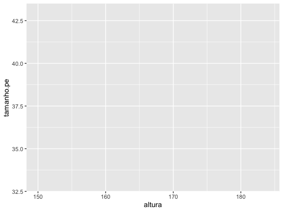

```r
# criando a estrutura básica do nosso gráfico

ggplot(linguistas.edit, aes(x = altura, y = tamanho.pe))
```

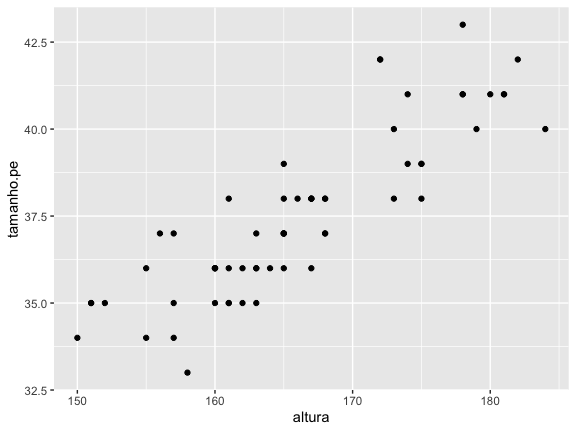

```r
# adicionando a camada de geometria, indicando geometria de pontos

ggplot(linguistas.edit, aes(x = altura, y = tamanho.pe))+
  geom_point()
```

- É possível que haja sobreposição dos pontos.
- Vamos mexer nas características dos pontos para adicionar transparência (`alpha`) e para modificar seu tamanho (`size`).

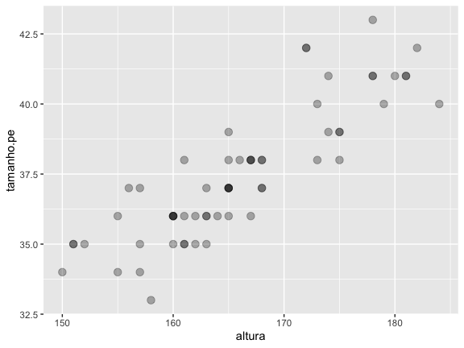

```r
# modificando os elementos introduzidos pela camada geometria

# o valor de alpha vai de 0 (completamente transparente) a 1 (completamente opaco)

ggplot(linguistas.edit, aes(x = altura, y = tamanho.pe))+
  geom_point(size = 3, alpha = 0.3)
```

- Ainda é possível adicionar um novo agrupamento de dados a partir dos elementos da geometria.
- Suponha que eu queira identificar, no elementro de geometria, o gênero do indivíduos; preciso fazer isso indicando a *estética* dessa geometria a partir da variável `genero`.

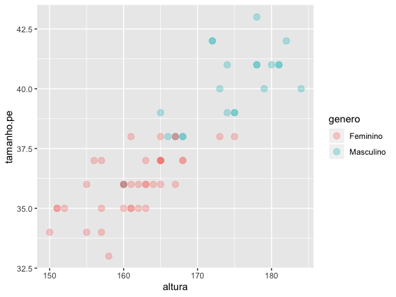

```r
# agrupando dados por nova variável na camada de geometria por meio de cor

ggplot(linguistas.edit, aes(x = altura, y = tamanho.pe))+
  geom_point(size = 3, alpha = 0.3, aes(color = genero))
```

- Se prefere não usar cores para isso, pode usar o formato dos elementos introduzidos na geometria.

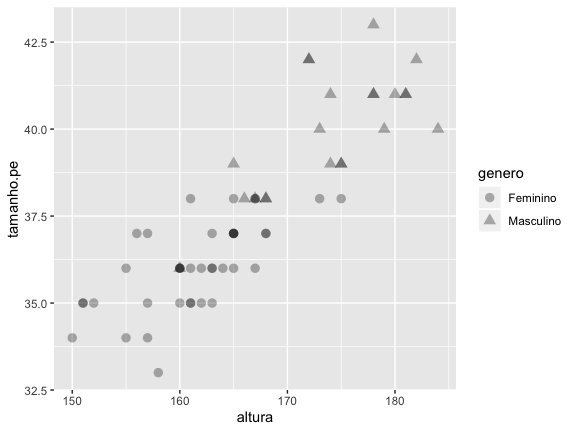

```r
# agrupando dados por nova variável na camada de geometria por meio de formato

ggplot(linguistas.edit, aes(x = altura, y = tamanho.pe))+
  geom_point(size = 3, alpha = 0.3, aes(shape = genero))
```

### Prática: gráficos de dispersão

- Leia o código abaixo e tente adivinhar que tipo de gráfico ele construiria. Depois rode o código e veja se você acertou.

```r
ggplot(linguistas.edit, aes(x = altura, y = peso))+
  geom_point(size = 3, alpha = 0.6, colour = "red")
```

- Leia o código abaixo e tente descobrir porque ele retorna um código de erro. Arrume o código.

```r
ggplot(linguistas.edit, aes(x = altura, y = peso))+
  geom_point(size = 2, alpha = 0.6, colour = genero)
```

- Crie um gráfico que demonstre a relação entre idade e peso, de modo a identificar se a idade é uma variável que influencia o peso de uma pessoa. Indique também, no gráfico, se a pessoa faz ou não atividade física, pois isso pode ser uma variável importante que influencia a relação entre peso e idade (pode ser que haja uma relação, mas essa relação some para quem faz atividade física).